# Analyzing interaction turnover (network dissimilarity)

**Goal**

Analyze whether experimental treatment of *Heliconia* removal resulted in the amount of pre-to-post interaction turnover, i.e., changes in interaction identity due to gain/loss of species OR reshuffling of interactions among species present throughout experiment.

Hypothesis: If hummingbird rewired to use alternative (non-*Heliconia*) resources, then there should be higher levels of network dissimilarity in treatment replicates relative to control replicates.

**Approach**

Using the ‘betalinkr’ function of the ‘bipartite’ R package, examine overall network dissimilarity and its two additive subcomponents: changes in interactions due to species gain/loss and changes in interactions among species present during both experimental periods (pre and post).

That is,

```
INTERACTION TURNOVER (total) = SPECIES TURNOVER + INTERACTION RESHUFFLING
```

Or, using the abbreviations of the package creators,

```
WN (whole network) = ST (species turnover) + OS (only shared, aka 'rewiring')
```

*Note that ‘rewiring’ in the context of the betalinkr function (rearrangement of interactions, not including gaining/losing species) is a more specific term than ‘rewiring’ in the general sense (meant to mean behavioral flexibility, which often does include gaining/losing species).*

Other notes:

- Due to potential differences in pre-to-post sampling completeness for pollen networks (script 08), will only analyze turnover for the visitation networks
- Will focus on binary versions of network dissimilarity, due to ease of interpretation (e.g., presence/absence of a given interaction or species). However, I will still analyze quantitative versions of metrics for the supplement.

## Step 1: Get data

Network dissimilarity has already been calculated (see script 04)

```r
#1. Get data
#2. Filter to visitation data, not pollen networks
#3. Remove outliers for sampling completeness identified in previous script; sampling completeness varies pre-to-post for these replicates
#4. Convert to long-form, rather than having one column per metric
turnover <- read.csv("../data/export/for_analysis/Network_dissimilarity_for_analysis.csv") %>%
  select(-X, -S, -OS.poisot) %>%
  mutate(year_patch = paste(year, patch, sep = "_")) %>%
  filter(sampling_method == "visitation") %>%
  filter(year_patch != "2017_130") %>%
  filter(year_patch != "2017_24") %>%
  pivot_longer(cols = c(WN, ST, OS), names_to = "metric", values_to = "value")

#Get functions
source("../scripts/helper_functions/Transform_proportion_for_betareg.R")
source("../scripts/helper_functions/Modeling_helper_functions.R")
source("../scripts/helper_functions/Plotting_helper_functions.R")
source("../scripts/helper_functions/Extract_data_from_safely_and_quietly_lists.R")

#Transform response variable to fall between 0 and 1 so can use beta regression, as in previous analyses
turnover_for_analysis <- turnover %>%
  group_by(binary) %>%
  mutate(value_transform = transform_proportion(value)) %>%
  ungroup()
```

## Step 2: Get organized

**Get organized**

Create structure to hole models and results (will have 6 models total)

```r
yvars = c("WN", "ST", "OS")
yvars_names = data.frame(yvars = yvars, yvars_names = c("Interaction turnover", "Species turnover", "Interaction turnover (shared species)"))
types = c("binary", "quant")

base_table <- crossing(yvars, types) %>%
  left_join(yvars_names) %>%
  arrange(types, yvars) %>%
  mutate(model_number = 1:length(types)) %>%
  mutate(model_id = paste(model_number, "camera", types, sep = "_")) %>%
  mutate(title = paste("camera", types, sep = "_")) %>%
  mutate(subtitle = yvars)
```

**Create function to subset data for each model of interest**

```r
#Function to subset data for each model of interest
subset_data <- function(dataset, type, yvar){

  if(type == "binary"){dataset <- dataset %>% filter(binary == TRUE)}
  if(type == "quant"){dataset <- dataset %>% filter(binary == FALSE)}

  #Response variable
  if(yvar == "WN"){dataset <- dataset %>% filter(metric == "WN")}
  if(yvar == "ST"){dataset <- dataset %>% filter(metric == "ST")}
  if(yvar == "OS"){dataset <- dataset %>% filter(metric == "OS")}

  return(dataset)

}

#Function to create models
create_model <- function(dataset, yvar){

  model <- eval(bquote(glmmTMB(.(as.formula(paste(yvar, "~ control_treatment + (1|patch)"))), data = dataset, na.action = na.omit, family = "beta_family")))

  return(model)

}
```

## Step 3: Analyze turnover metrics

**Create models**

```r
models <- base_table %>%
  mutate(data = pmap(list(types, yvars), ~subset_data(dataset = turnover_for_analysis, type = ..1, yvar = ..2))) %>%
  mutate(model_quietly = pmap(list(data), quietly(function(a){model <- create_model(dataset = a, yvar = "value_transform")})),
         model = map(model_quietly, get_result),
         warning = map(model_quietly, get_warning),
         convergence = map(model, check_convergence)) %>%
  mutate(xvar_table = map(model, ~data.frame(xvar = all.vars(terms(.))[-1])))

#Make sure there weren't any problems + check to make sure table of predictor variables is correct
# models$warning
# models$convergence
# models$xvar_table
```

**Check assumptions**

```r
assumption_checks <- models %>%
  mutate(re_plot = pmap(list(model, title, subtitle), ~check_re(model = ..1, plot_title = ..2, plot_subtitle = ..3))) %>%
  mutate(dharma_object = map(model,
                             ~simulateResiduals(fittedModel = ., n = 1000, plot = FALSE, re.form = ~0))) %>%
  mutate(dharma_plot_safely = pmap(list(dharma_object, title, subtitle),
                                   safely(function(a, b, c){make_dharma_plot(dharma_object = a, plot_title = b, plot_subtitle = c, plot_type = "basic")})),
         dharma_plot = map(dharma_plot_safely, get_result)) %>%
  mutate(dharma_xvar_plot = pmap(list(xvar_table, data, dharma_object, title, subtitle),
                                 ~make_dharma_xvar_plot(predictor_table = ..1, dataset = ..2, dharma_object = ..3, plot_title = ..4, plot_subtitle = ..5))) %>%
  mutate(plotname1 = paste("re_diagnostics_", model_id, ".png", sep = "")) %>%
  mutate(plotname2 = paste("dharma_overall_diagnostics_", model_id, ".png", sep = "")) %>%
  mutate(plotname3 = paste("dharma_xvar_diagnostics_", model_id, ".png", sep = ""))
```

```r
#Export diagnostic plots because they load very slowly in RStudio
path_name <- c("../results/analyses_experiment/interaction_turnover/assumption_checks")
walk2(assumption_checks$plotname1, assumption_checks$re_plot, ~ggsave(filename = .x, plot = .y, path = path_name, height = 11.5, width = 15, units = "in", bg = "white"))
walk2(assumption_checks$plotname2, assumption_checks$dharma_plot, ~ggsave(filename = .x, plot = .y, path = path_name, height = 11.5, width = 15, units = "in"))
walk2(assumption_checks$plotname3, assumption_checks$dharma_xvar_plot, ~ggsave(filename = .x, plot = .y, path = path_name, height = 11.5, width = 15, units = "in"))
```

**Check for highly influential replicates**

```r
#Make plots of DFBETAS and Cook's distance
influence_checks <- models %>%
  mutate(influence_plot = pmap(list(model, data, title, subtitle), ~make_influence_plot(model = ..1, dataset = ..2, plot_title = ..3, plot_subtitle = ..4, group_id = "year_patch"))) %>%
  mutate(plotname4 = paste("influence_diagnostics_", model_id, ".png", sep = ""))
```

```r
#Export plots
path_name <- c("../results/analyses_experiment/interaction_turnover/assumption_checks")
walk2(influence_checks$plotname4, influence_checks$influence_plot, ~ggsave(filename = .x, plot = .y, path = path_name, height = 11.5, width = 15, units = "in", bg = "white"))
```

**Create model summaries, calculate confidence intervals, and tidy results into dataframe for export**

```r
#Will also add information about sample size: total # of observations (rows), number of levels per random effect, and the number of replicates (split into 'control' vs. 'treatment')
results <- models %>%
  mutate(summary = map(model, summary),
         summary_tidy = map(model, broom.mixed::tidy),
         confint_wald = map(model, ~calculate_ci(., method_name = "wald"))) %>%
  mutate(num_obs = map(model, get_number_obs),
         num_levels = map(model, get_number_re_levels),
         num_reps = map(data, ~get_sample_size(data = ., vars = c("year", "patch", "control_treatment"), grouping_var = "control_treatment")))

#Extract model summaries
results_tidy <- results %>%
  select(model_number, types, yvars, summary_tidy) %>%
  unnest(c(summary_tidy))

#Extract confidence intervals
results_confint <- results %>%
  select(model_number, types, yvars, confint_wald) %>%
  mutate(confint_df = map(confint_wald, as.data.frame)) %>% #CI as dataframe
  mutate(confint_df = map(confint_df, ~tibble::rownames_to_column(., var = "term"))) %>%
  unnest(cols = confint_df) %>%
  rename(lowerCI = "2.5 %", upperCI = "97.5 %") %>%
  select(-confint_wald, -Estimate)

#Back-transform coefficients and confidence intervals to data scale from model scale
results_tidy_confint <- results_tidy %>%
  left_join(results_confint) %>%
  mutate_at(vars(estimate, lowerCI, upperCI), .funs = list(exp = ~ifelse(effect == "fixed", exp(.), NA))) %>%
  mutate_at(vars(estimate, std.error, statistic, lowerCI, upperCI, estimate_exp, lowerCI_exp, upperCI_exp), ~round(., digits = 2)) %>%
  mutate(pvalue_round = format.pval(pv = p.value, digits = 2, eps = 0.001)) %>%
  select(model_number:term, estimate, lowerCI, upperCI, statistic, pvalue_round, pvalue = p.value, std_error = std.error, everything())

#Extract number of reps for each dataset
sample_size <- results %>%
  select(model_number, types, yvars, num_obs, num_reps) %>%
  unnest(cols = num_reps) %>%
  mutate(num_obs = unlist(num_obs))
```

**Calculate estimated marginal means and contrasts**

```r
#Function to calculate contrasts of 'probabilities' (not really probabilities, because they're actually indices, but on response scale)
calculate_contrasts <- function(model){

  emm = emmeans(model, specs = ~control_treatment)
  emm_log = regrid(emm, transform = "log")
  #result = summary(contrast(emm_log, interaction = "revpairwise"), type = "response") #Without CI, with p-value
  result = confint(contrast(emm_log, interaction = "revpairwise"), type = "response") #With CI, without p-value

  return(result)

}

emmeans_contrasts <- results %>%
  mutate(ggeffects = map(model, ~ggemmeans(., terms = c("control_treatment"), back.transform = TRUE))) %>%
  mutate(emm = map(model, ~emmeans(., specs = ~control_treatment))) %>%
  mutate(contrasts = purrr::map(model, calculate_contrasts))

emmeans <- emmeans_contrasts %>%
  select(model_number, types, yvars, ggeffects) %>%
  unnest(cols = c(ggeffects))

contrasts <- emmeans_contrasts %>%
  select(model_number, types, yvars, contrasts) %>%
  unnest(contrasts) %>%
  mutate_if(is.numeric, ~round(., digits = 3))
```

**Plot results**

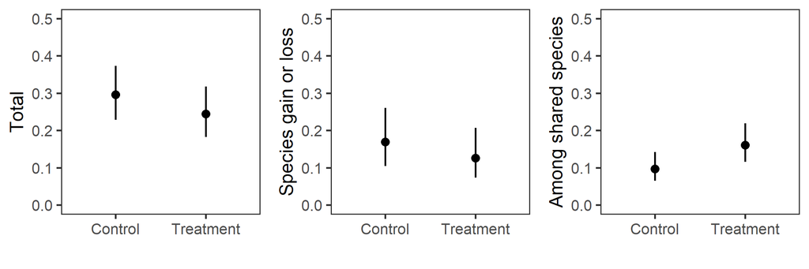

```r
plots <- emmeans_contrasts %>%
  mutate(plot = pmap(list(ggeffects, yvars), ~make_control_vs_treatment_plot(ggeffects_df = ..1, yvar = ..2, ymax = 0.5)))

#Make multiplot (BINARY)
plots_binary <- plots %>%
  mutate(yvars = factor(as.character(yvars), levels = c("WN", "ST", "OS"), ordered = TRUE)) %>%
  filter(types == "binary") %>%
  arrange(yvars)

multiplot_binary <- ggarrange(plotlist = plots_binary$plot, nrow = 1, ncol = 3, legend = "none")
multiplot_binary
```

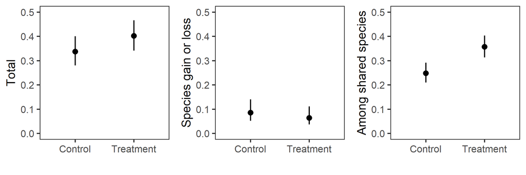

```r
#Make multiplot (QUANTITATIVE)
plots_quant <- plots %>%
  mutate(yvars = factor(as.character(yvars), levels = c("WN", "ST", "OS"), ordered = TRUE)) %>%
  filter(types == "quant") %>%
  arrange(yvars)

multiplot_quant <- ggarrange(plotlist = plots_quant$plot, nrow = 1, ncol = 3, legend = "none")
multiplot_quant
```

## Step 4: Export results

```r
path_name <- c("../results/analyses_experiment/interaction_turnover")

#Summary tables
write.csv(results_tidy_confint, file.path(path_name, "tables/Turnover_results_summary_tables.csv"))
write.csv(sample_size, file.path(path_name, "tables/Turnover_results_sample_size_summary.csv"))
write.csv(emmeans, file.path(path_name, "tables/Turnover_results_emmeans.csv"))
write.csv(contrasts, file.path(path_name, "tables/Turnover_results_contrasts.csv"))

#Plots
ggsave(file.path(path_name, "figures/Turnover_multiplot_binary.png"), multiplot_binary, dpi = 300, units = "in", width = 12, height = 4, bg = "white")
ggsave(file.path(path_name, "figures/Turnover_multiplot_quant.png"), multiplot_quant, dpi = 300, units = "in", width = 12, height = 4, bg = "white")
```